# Instruction for item labeling

## 1. GPU

| Description | Label |
| --- | --- |
| NVIDIA GeForce GTX 1xxx series | 0 |
| NVIDIA other than above | 1 |
| Intel HD Graphics 4xxx/5xxx | 2 |
| Intel HD Graphics 6xxx | 3 |
| (Integrated) Intel HD Graphics | 4 |
| AMD Radeon R2-4 | 5 |
| AMD Radeon R5-7 | 6 |
| others | 7 |

## 2. Hard Disk

| Description | Label |
| --- | --- |
| SSD, (0, 16G] | 0 |
| SSD (16, 32G] | 1 |
| SSD (32, 128] | 2 |
| SSD (128, 256] | 3 |
| SSD (256, 512] | 4 |
| HDD (0, 256G] | 5 |
| HDD (256G, 512] | 5 |
| HDD (512-1T] | 6 |
| HDD (1T, ) | 7 |
| others | 4 |

## 3. RAM

| Description | Label |
| --- | --- |
| 2/4 GB SDRAM DDR3 | 0 |
| 6 GB DDR SDRAM DDR3/DDR4 | 1 |
| 8 GB SDRAM DDR3 | 2 |
| 8 GB SDRAM DDR4 | 3 |
| 12 GB DDR SDRAM | 4 |
| 16 GB DDR4 | 5 |

## 4. CPU

| Description | Label |
| --- | --- |
| Intel Celeron/ADM A (0, 2GHz) | 0 |
| Intel Celeron/ADM A ([2, 3)GHz | 1 |
| Intel Celeron/ADM A ([3, )GHz | 2 |
| Intel i3 (0, 2.4) GHz | 3 |
| Intel i3 [2.4, ) GHz | 4 |
| Intel i5 (0, 2] GHz | 5 |
| Intel i5 (2, 3) GHz | 6 |
| Intel i5 [3, ) GHz | 7 |
| Intel i7 (0, 2] GHz | 6 |
| Intel i7 (2, 3] GHz | 7 |
| Intel i7 [3, ) GHz | 8 |
| Others | 9 |

## 5. Screen

| Description | Label |
| --- | --- |
| 10.1/11.6 inch | 0 |
| 13.3 inch | 1 |
| 14.0 inch | 2 |
| 15.6 inch | 3 |
| 17.3 inch | 4 |
| 19.5 inch | 5 |

# Summary of data

Totally 1,790 sentences are collected, which are divided into train/dev/test set, e.g., 1,576/83/131 for the experiments. There are 25,335 tokens (or 1,238 unique words), including punctuations. The sentence lengths vary from 4 to 35, with median value 13. The distribution of the sentence lengths is shown below:

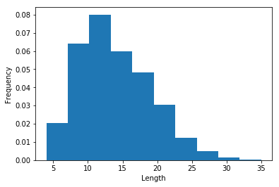

```python
%matplotlib inline
import matplotlib.pyplot as plt
import numpy as np
import json
# load data containing length
length = np.load("output/length.npy")
plt.hist(length, normed=True, bins=10)
plt.xlabel("Length")
plt.ylabel("Frequency")
plt.show()
```

```python
import json
def load_json(filepath):
    with open(filepath) as f:
        return json.load(f)
```

It is also noted that data suffer from imbalance problem, as shown below:

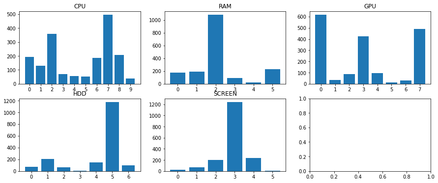

```python
data_dist = load_json("output/data_dist.json")
# prepare plot
n_rows = 2
n_cols = 3
fig, ax = plt.subplots(nrows=n_rows, ncols=n_cols, figsize=(15,6))
i, j = 0, 0
for item, label_counter in data_dist.items():
    if j >= n_cols:
        i += 1
        j = 0
    label = sorted(list(label_counter.keys()))
    count = [label_counter[l] for l in label]
    ax[i][j].bar(label, count)
    ax[i][j].title.set_text(item.upper())
    j += 1
#     plt.bar(label, count)
#     plt.xlabel("label"), plt.ylabel("number of texts")
#     plt.title(item.upper())
plt.show()
```

### Experimental results

The training configurations are the same as previous report. Here precision@k are provided. Please note that the reported scores may be a little bit different from the previous ones (but not significant), because of random initialized parameters (the minor difference still exits even though the random seed is fixed). The precision@k and recall@k are calculated using [**sklean.metrics**](https://scikit-learn.org/stable/modules/generated/sklearn.metrics.precision_score.html) for fair comparison. To compute precision and recall, a hyper-parameter **average** needs specification. Two choices, i.e., **micro** and **marco** are provided. By selecting the global parameter **average**, the corresponding values will be displayed.

```python
def simple_table(scores, max_len, average="micro", metrics="precision"):

    key = "%s_%s" % (metrics, average)
    item_list = list(scores.keys())
    header = ["%s@%s" % (metrics[0].upper(), i) for i in range(1, max_len+1)]

    data = []
    for item_scores in scores.values():
        value = []
        for score in item_scores.values():
            value.append(score[key])
        if len(value) < max_len:
            value += ["-"] * (max_len-len(value))
        data.append(value)

    # print row format
    row_format ="{:>10}" * (len(header) + 1)
    print(row_format.format("", *header))
    for item, row in zip(item_list, data):
        print(row_format.format(item, *row))
```

```python
# the default is micro. Pay attention that the precision and recall are the same for this setting
average = "micro"
# maximum number of classes
max_num_class = 10
# load scores
scores = load_json("output/scores.json")
# pricision
print("Precision@k:")
simple_table(scores, max_num_class, average, metrics="precision")
print("-"*100)
print("Recall@k:")
# recall
simple_table(scores, max_num_class, average, metrics="recall")
# print("-"*100)
# print("F1@k:")
# F1
# simple_table(scores, max_num_class, average, metrics="f1")
```

```
Precision@k:
                 P@1       P@2       P@3       P@4       P@5       P@6       P@7       P@8       P@9      P@10
       cpu     0.298     0.229     0.193     0.168     0.156     0.139      0.13     0.118     0.109       0.1
       ram     0.534     0.378     0.272     0.225     0.188     0.167         -         -         -         -
       gpu     0.397     0.317      0.26     0.225     0.186      0.16      0.14     0.125         -         -
       hdd     0.603     0.385      0.28     0.219     0.188     0.163     0.143         -         -         -
    screen     0.679     0.427     0.308     0.242     0.197     0.167         -         -         -         -
----------------------------------------------------------------------------------------------------
Recall@k:
                 R@1       R@2       R@3       R@4       R@5       R@6       R@7       R@8       R@9      R@10
       cpu     0.298     0.458      0.58     0.672     0.779     0.832     0.908     0.947     0.977       1.0
       ram     0.534     0.756     0.817     0.901     0.939       1.0         -         -         -         -
       gpu     0.397     0.634     0.779     0.901     0.931     0.962     0.977       1.0         -         -
       hdd     0.603     0.771      0.84     0.878     0.939     0.977       1.0         -         -         -
    screen     0.679     0.855     0.924     0.969     0.985       1.0         -         -         -         -
```

## Experimental results for testing impact of text length on performance

However, if the text is long enough, e.g., two problems would arise: 1) it is out of the model capacity; and 2) the predicted performance will be poor.

```python
def long_short_text_plot(scores, average="micro"):
    items = []
    short_scores = []
    long_scores = []
    for item, value in scores.items():
        items.append(item.upper())
        short_score = value["short"]["recall_%s" % average]
        long_score = value["long"]["recall_%s" % average]
        short_scores.append(float(short_score))
        long_scores.append(float(long_score))

    print("recall for short texts:", short_scores)
    print("recall for long texts:", long_scores)

    # create plot
    n_groups = 5
    fig, ax = plt.subplots()
    index = np.arange(n_groups)
    bar_width = 0.35
    opacity = 0.8

    rects1 = plt.bar(index, short_scores, bar_width,
    alpha=opacity,
    color='b',
    label='Short')

    rects2 = plt.bar(index + bar_width, long_scores, bar_width,
    alpha=opacity,
    color='g',
    label='Long')

    plt.xlabel('Item')
    plt.ylabel('Recall')
    plt.xticks(index + bar_width, items)
    plt.legend()

    plt.show()
```

```
recall for short texts: [0.267, 0.531, 0.367, 0.576, 0.677]
recall for long texts: [0.324, 0.537, 0.423, 0.625, 0.681]
```

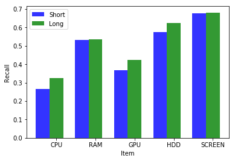

```python
scores_by_length = load_json("output/scores_by_length.json")
long_short_text_plot(scores_by_length)
```

## Expriment on data imbalance

According to data distribution, the data is highly imbalanced. In roder to test CNN's sensitivity on data imbalance, we re-group the training data. Here is strategy:

1. divide the total dataset into 2 or 3 groups, based on the number of certain labeled texts. In each group, the labeled text for each class is more balanced than without grouping.
2. Train & test model for each group. The data is divided into train/test set based on 0.9/0.1 ratio. No dev data is generated. All model & training configurations are the same except selecting training epochs 3.

We choose CPU for example. Here are the data distribution: { "6": 187, "2": 357, "0": 194, "1": 130, "7": 497, "5": 54, "8": 206, "9": 39, "4": 55, "3": 71 }. Then labels (7, 2, 8, 0, 6) and (1, 3, 4, 5, 9) are grouped together to generate two seperated datasets, and labels (7, 2, 8), (0, 6, 1) and (3, 4, 5, 9) are grouped to generate three seperated datasets.

One problem is that the training data will be fewer after re-grouping. Intuitively, groups where training data are sufficient will obtain better results than the groups with insufficient data, even though the data are distributed evenly accross labels. Results are shown below.

```python
def group_plot(item="cpu", k=None, metrics="recall", average="micro", group_index=0, num_class=10):
    assert item == "cpu"
    ks = [str(i) for i in range(1, num_class+1)]
    if k is not None:
        ks = k.split(",")

    scores_1 = load_json("output/scores.json")
    scores_23 = load_json("output/by_group/scores.json")

    legend_text = []
    for k in ks:
        try:
            k_score_1 = float(scores_1[item][k]["%s_%s" % (metrics, average)])
            k_score_2 = float(scores_23["%s_2%s" % (item, group_index)][k]["%s_%s" % (metrics, average)])
            k_score_3 = float(scores_23["%s_3%s" % (item, group_index)][k]["%s_%s" % (metrics, average)])
            k_scores = [k_score_1, k_score_2, k_score_3]
            legend_text.append(metrics[0].upper()+"@"+k)
            index = [1, 2, 3]
            plt.plot(index, k_scores, "-o")
        except:
            pass
    plt.legend(legend_text)
    plt.xticks([1, 2, 3], [1, 2, 3])
    plt.xlabel("Group by label frequency")
    plt.title("%s/2 Group" % (group_index+1))
    plt.show()
```

```python
scores = {
    "7": {
        "presicion": [0.304, 0.526, 0.678],
        "recall": [0.774, 0.732, 0.784],
        "f1": [0.44, 0.61, 0.73]
    },
    "4": {
        "presicion": [0.00, 0.333, 0.75],
        "recall": [0.00, 0.20, 0.50],
        "f1": [0.00, 0.25, 0.60]
    }
}
```

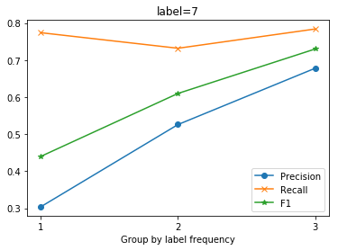

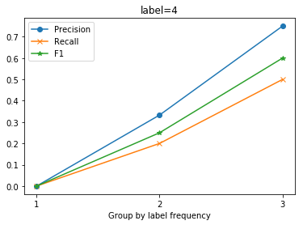

```python
index = [1, 2, 3]
for label, score_ in scores.items():
    plt.plot(index, score_["presicion"], "-o")
    plt.plot(index, score_["recall"], "-x")
    plt.plot(index, score_["f1"], "-*")
    plt.legend(["Precision", "Recall", "F1"])
    plt.xlabel("Group by label frequency")
    plt.title("label=%s" % label)
    plt.xticks([1, 2, 3], [1, 2, 3])
    plt.show()
```